# Seaborn

## Contextualizando

O [Matplotlib](https://matplotlib.org/) é uma biblioteca muito potente pra criação de gráficos dos mais diversos tipos, porém por ser tão genérico acaba que pra certas aplicações, como a nossa por exemplo, algumas tarefas acabam por não ser otimizadas da melhor maneira possível, ao menos no quesito de comunicar a linguagem o que queremos. É justamente ai que entra o [Seaborn](https://seaborn.pydata.org/), uma biblioteca feita em cima do Matplotlib, porém com enfase em estatística e ciência de dados. Pra começar, o Seaborn é muito bem integrado com o [Pandas](https://pandas.pydata.org/), ou seja, conseguimos utilizar os `DataFrames` do Pandas pra plotar gráficos com facilidade. Além disso, como é baseado no Matplotlib, temos o grande poder que apresenta, mas de uma maneira mais amigável pra nossa aplicação.

Iremos importar o `seaborn` como `sns`.

```python
import seaborn as sns
```

O Seaborn vem com alguns [bancos](https://github.com/mwaskom/seaborn-data) para serem utilizados como exemplos e também testar suas funcionalidades. Carregando um desses bancos, vemos que eles são os `DataFrames` do Pandas, ou seja, é um caso bem semelhante ao que normalmente iremos usar.

```python
iris = sns.load_dataset("iris")
print(type(iris))
```

```
<class 'pandas.core.frame.DataFrame'>
```

```python
iris
```

|  | sepal_length | sepal_width | petal_length | petal_width | species |
| --- | --- | --- | --- | --- | --- |
| 0 | 5.1 | 3.5 | 1.4 | 0.2 | setosa |
| 1 | 4.9 | 3.0 | 1.4 | 0.2 | setosa |
| 2 | 4.7 | 3.2 | 1.3 | 0.2 | setosa |
| 3 | 4.6 | 3.1 | 1.5 | 0.2 | setosa |
| 4 | 5.0 | 3.6 | 1.4 | 0.2 | setosa |
| ... | ... | ... | ... | ... | ... |
| 145 | 6.7 | 3.0 | 5.2 | 2.3 | virginica |
| 146 | 6.3 | 2.5 | 5.0 | 1.9 | virginica |
| 147 | 6.5 | 3.0 | 5.2 | 2.0 | virginica |
| 148 | 6.2 | 3.4 | 5.4 | 2.3 | virginica |
| 149 | 5.9 | 3.0 | 5.1 | 1.8 | virginica |

150 rows × 5 columns

# Gráficos de dispersão

Para fazermos gráficos de dispersão, usamos a função `scatterplot` do Seaborn.

Aqui já começamos a ver algumas diferenças bem interessantes entre ele e o Matplotlib. Podemos plotar um gráfico usando exatamente os mesmos parâmetros, informando no eixo `x` e `y` um banco e sua coluna, e mesmo assim, já podemos ver uma vantagem, o gráfico já vem com legendas automaticamente, no caso, o nome das colunas.

Estamos usando o comando `sns.set()` pra definir um tema estético padrão do seaborn, mas podemos utilizar outros do seaborn, como também os que estávamos utilizando no Matplotlib.

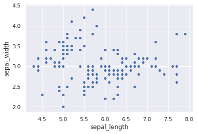

```python
sns.set()
sns.scatterplot(x = iris["sepal_length"], y =  iris["sepal_width"])
```

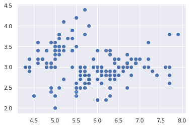

```python
import matplotlib.pyplot as plt
plt.scatter(x = iris["sepal_length"], y = iris["sepal_width"])
```

Conseguimos então fazer um gráfico que já vem com legendas, porém obviamente isso não é justificativa pra usar uma biblioteca diferente. As reais vantagens começam a aparecer quando precisamos fazer coisas que vão além de passar um argumento pro `x` e outro pro `y` (ou seja, sempre). Semelhante ao `ggplot2` do R, podemos setar um banco para o plot, ou seja, não precisamos escrever a todo momento o banco que estamos nos referindo. Isso é feito através do argumento `data`.

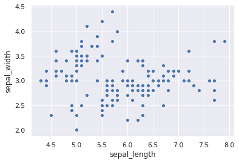

```python
sns.scatterplot(data = iris, x = "sepal_length", y =  "sepal_width")
```

Agora que já temos um banco definido, podemos facilmente definir cores diferentes de acordo com outra variável por exemplo. Para isso passamos o parâmetro `hue` atrelado a uma coluna.

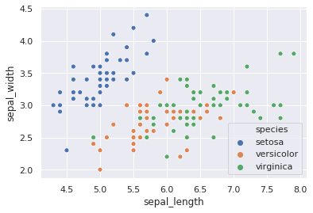

```python
sns.scatterplot(data = iris, x = "sepal_length", y =  "sepal_width", hue = "species")
```

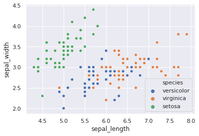

```python
sns.scatterplot(data = iris, x = "sepal_length", y =  "sepal_width", hue = "species",
               hue_order = ["versicolor","virginica","setosa"])
```

Obviamente podemos também mudar as cores utilizadas, e isso será feito através do `palette`. Aqui temos muitas opções, podemos informar o nome de uma paleta, e ela atribuir as cores pela ordem dos itens, podemos também informar uma lista de cores, ou até mesmo um dicionario, com as informações de cores e valores, como `key:value`, nesse ultimo caso as cores são atribuídas aos valores independente da ordem.

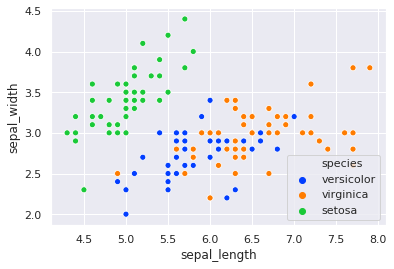

```python
sns.scatterplot(data = iris, x = "sepal_length", y =  "sepal_width", hue = "species",
                palette = "bright", hue_order = ["versicolor","virginica","setosa"])
```

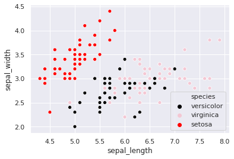

```python
cores = ["black","#f4c7d3","red"]
sns.scatterplot(data = iris, x = "sepal_length", y =  "sepal_width", hue = "species",
                palette = cores, hue_order = ["versicolor","virginica","setosa"])
```

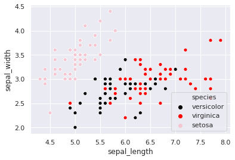

```python
cores = {"versicolor":"black","setosa":"#f4c7d3","virginica":"red"}
sns.scatterplot(data = iris, x = "sepal_length", y =  "sepal_width", hue = "species",
                palette = cores, hue_order = ["versicolor","virginica","setosa"])
```

# Gráficos de Relação

O `relplot` serve para fazermos gráficos de dispersão e também de linha, porém com algumas outras funções muito uteis pra comparações e relações entre variáveis. Para escolhermos o tipo do gráfico, precisamos escolher entre `line`e `scatter`, e passar no parâmetro `kind` (teoricamente não precisamos escolher o `kind` pra gráficos de dispersão pois ele é o default, mas por clareza de leitura é interessante especificar mesmo assim).

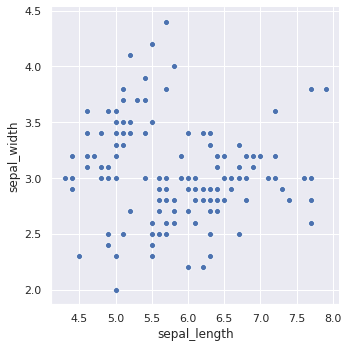

```python
sns.relplot(data = iris, x = "sepal_length", y =  "sepal_width")
```

O grande atrativo do `relplot` é a facilidade de fazermos subplots. Para isso, basta passarmos uma variável no `row`, `col` ou ambos. A função do `relplot` então vai dividir em subgráficos de acordo com a variável que passarmos.

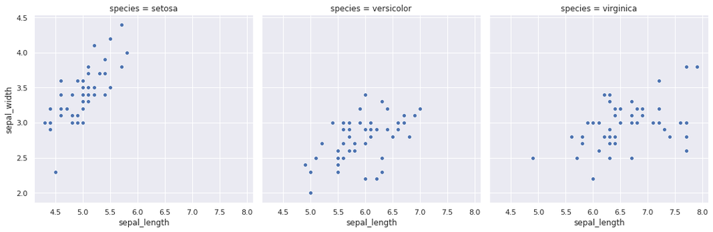

```python
sns.relplot(data = iris, x = "sepal_length", y =  "sepal_width", col = "species")
```

```python
mpg = sns.load_dataset("mpg")
mpg
```

|  | mpg | cylinders | displacement | horsepower | weight | acceleration | model_year | origin | name |
| --- | --- | --- | --- | --- | --- | --- | --- | --- | --- |
| 0 | 18.0 | 8 | 307.0 | 130.0 | 3504 | 12.0 | 70 | usa | chevrolet chevelle malibu |
| 1 | 15.0 | 8 | 350.0 | 165.0 | 3693 | 11.5 | 70 | usa | buick skylark 320 |
| 2 | 18.0 | 8 | 318.0 | 150.0 | 3436 | 11.0 | 70 | usa | plymouth satellite |
| 3 | 16.0 | 8 | 304.0 | 150.0 | 3433 | 12.0 | 70 | usa | amc rebel sst |
| 4 | 17.0 | 8 | 302.0 | 140.0 | 3449 | 10.5 | 70 | usa | ford torino |
| ... | ... | ... | ... | ... | ... | ... | ... | ... | ... |
| 393 | 27.0 | 4 | 140.0 | 86.0 | 2790 | 15.6 | 82 | usa | ford mustang gl |
| 394 | 44.0 | 4 | 97.0 | 52.0 | 2130 | 24.6 | 82 | europe | vw pickup |
| 395 | 32.0 | 4 | 135.0 | 84.0 | 2295 | 11.6 | 82 | usa | dodge rampage |
| 396 | 28.0 | 4 | 120.0 | 79.0 | 2625 | 18.6 | 82 | usa | ford ranger |
| 397 | 31.0 | 4 | 119.0 | 82.0 | 2720 | 19.4 | 82 | usa | chevy s-10 |

398 rows × 9 columns

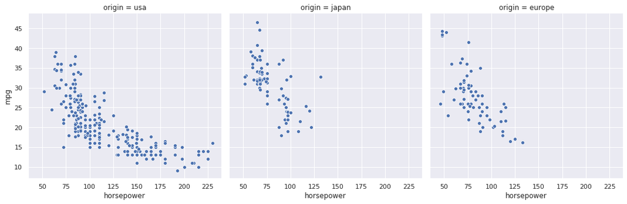

```python
sns.relplot(data = mpg, x = "horsepower", y =  "mpg", col = "origin")
```

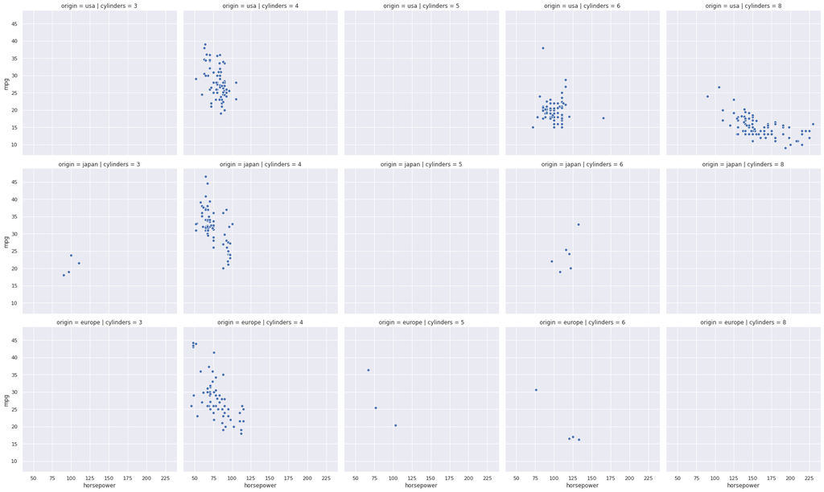

```python
sns.relplot(data = mpg, x = "horsepower", y =  "mpg", row = "origin", col = "cylinders")
```

Podemos também passar os argumentos estéticos que já vimos anteriormente, sem problemas. Iremos aprender mais alguns agora, e normalmente esses argumentos são os mesmos independente do tipo de gráfico.

Além disso, podemos também especificar a ordem dos valores que aparecem nas colunas ou linhas, passando uma lista com a ordem desejada no parâmetro `col_order` e/ou `row_order`.

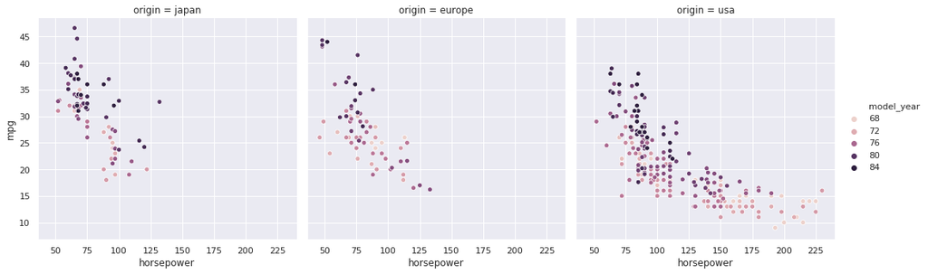

```python
sns.relplot(data = mpg, x = "horsepower", y =  "mpg", hue = "model_year",
           col = "origin", col_order = ["japan","europe","usa"])
```

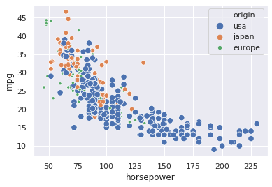

```python
sns.scatterplot(data = mpg, x = "horsepower", y =  "mpg",
                size = "origin", hue = "origin")
```

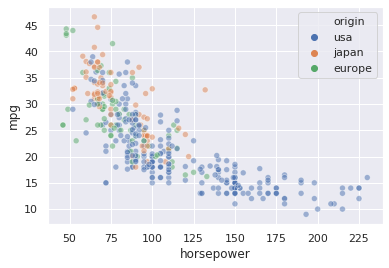

```python
sns.scatterplot(data = mpg, x = "horsepower", y =  "mpg",
                hue = "origin", alpha = 0.5)
```

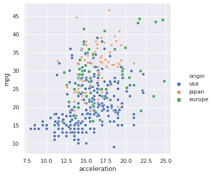

```python
sns.relplot(data = mpg, x = "acceleration",y="mpg", kind = "scatter",
            hue = "origin",style = "origin")
```

# Gráficos de Linha

Como mencionamos anteriormente, podemos, além do gráfico de dispersão, fazer gráficos de linha com o `relplot`. Nos exemplos a seguir não veremos diferença entre o `relplot`, e o `lineplot`, porém seguiremos usando o `relplot` pois seu uso é mais genérico.

Ao chamarmos o gráfico de linhas, se tivermos mais de uma observação pra cada valor do `x`, automaticamente será calculada a média dos valores para poder ser representado no gráfico. Além disso, um intervalo de confiança de 95% também acompanha a linha, assumindo que o banco é uma amostra aleatória.

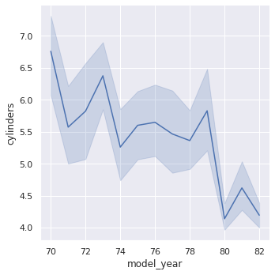

```python
sns.relplot(data = mpg, kind = "line", x = "model_year", y = "cylinders")
```

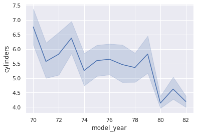

```python
sns.lineplot(data = mpg, x = "model_year", y = "cylinders")
```

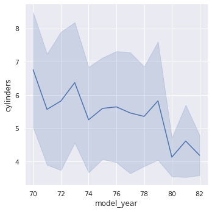

```python
sns.relplot(data = mpg, kind = "line", x = "model_year", y = "cylinders", ci = "sd")
```

Pra finalizar, nos gráficos de linhas, ainda temos alguns estéticos novos, como o `markers` pra incluir marcadores nos pontos que temos dados, e o `dashes` pra definir o tipo de linha utilizado.

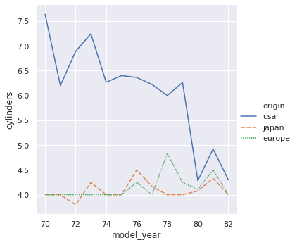

```python
sns.relplot(data = mpg, kind = "line", x = "model_year", y = "cylinders",
            ci = None, style = "origin", hue = "origin")
```

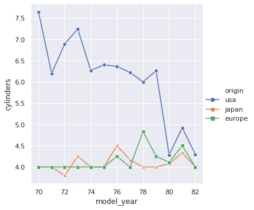

```python
sns.relplot(data = mpg, kind = "line", x = "model_year", y = "cylinders",
            ci = None, style = "origin", hue = "origin",
            markers = True, dashes = False)
```